# Hypothesis Tests for Categorical Variables

# Your Turn

## Grades and Classroom Type

Use the data below containing counts of grades and classroom types to answer the questions below.

Create a Bar Chart using ggplot().

```r
course <- import('https://raw.githubusercontent.com/byuistats/Math221D_Cannon/master/Data/course_type_by_grade.csv')
glimpse(course)
```

```
Rows: 207
Columns: 2
$ Grade       <chr> "A", "A", "A", "A", "A", "A", "A", "A", "A", "A", "A", "A"…
$ Course_Type <chr> "Traditional", "Traditional", "Traditional", "Traditional"…
```

```r
table(course)
```

```
     Course_Type
Grade Online Traditional
    A     14          26
    B     26          31
    C     23          40
    D     11          21
    F      6           9
```

Create a Bar Chart using ggplot()

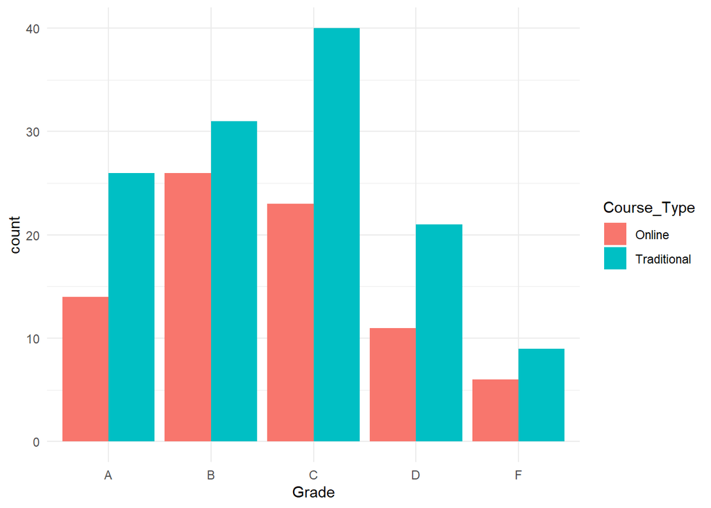

```r
ggplot(course, aes(x = Grade, fill = Course_Type)) +
  geom_bar(position = "dodge") +
  theme_minimal()
```

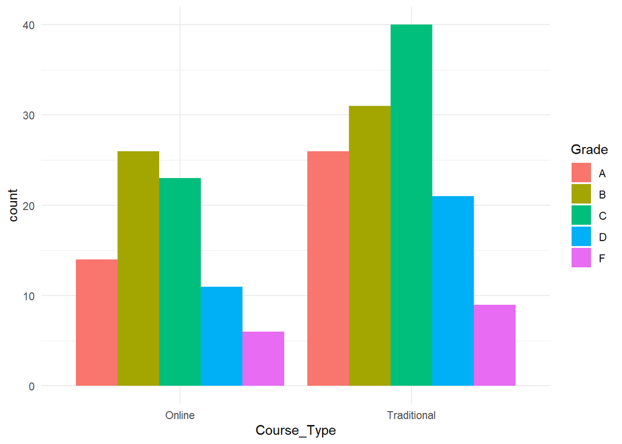

```r
ggplot(course, aes(x = Course_Type, fill = Grade)) +
  geom_bar(position = "dodge") +
  theme_minimal()
```

Perform the $\chi^2$ test of independence.

```r
chisq.test(table(course$Grade, course$Course_Type))
```

```
    Pearson's Chi-squared test

data:  table(course$Grade, course$Course_Type)
X-squared = 1.7707, df = 4, p-value = 0.7778
```

```r
chisq.test(table(course$Grade, course$Course_Type))$expected
```

```
       Online Traditional
  A 15.458937   24.541063
  B 22.028986   34.971014
  C 24.347826   38.652174
  D 12.367150   19.632850
  F  5.797101    9.202899
```

```r
chisq.test(table(course$Grade, course$Course_Type))$expected >= 5
```

```
    Online Traditional
  A   TRUE        TRUE
  B   TRUE        TRUE
  C   TRUE        TRUE
  D   TRUE        TRUE
  F   TRUE        TRUE
```

**Question**: Are the requirements for a $\chi^2$ test satisfied?  
**Answer**: Yes!

**Question**: What are the null and alternative hypotheses? **Answer**:
$$H_0: \text{Your grade is independent of your course type}$$
$$H_a: \text{Your grade is not independent of your course type}$$

**Question**: What is the test statistic, $\chi^2$? **Answer**: 1.7707

**Question**: How many degrees of freedom does this test have? **Answer**: 4

**Question**: What is the P-value? **Answer**: 0.7778